# 1. Introduction

# 2 Related Literature

There are two approaches that are dominant in the literature in forecasting solar power. These two approaches are the normalized clear sky model such as the one developed by Bacher et al.(2009) and neural networks with different inputs. The rationale behind the clear sky model is to create a stationary time series so that working with the data becomes easier and easier to interpret. The neural networks approach is used to predict the solar power directly. However, our approach is more similar to the clear-sky-normalized.

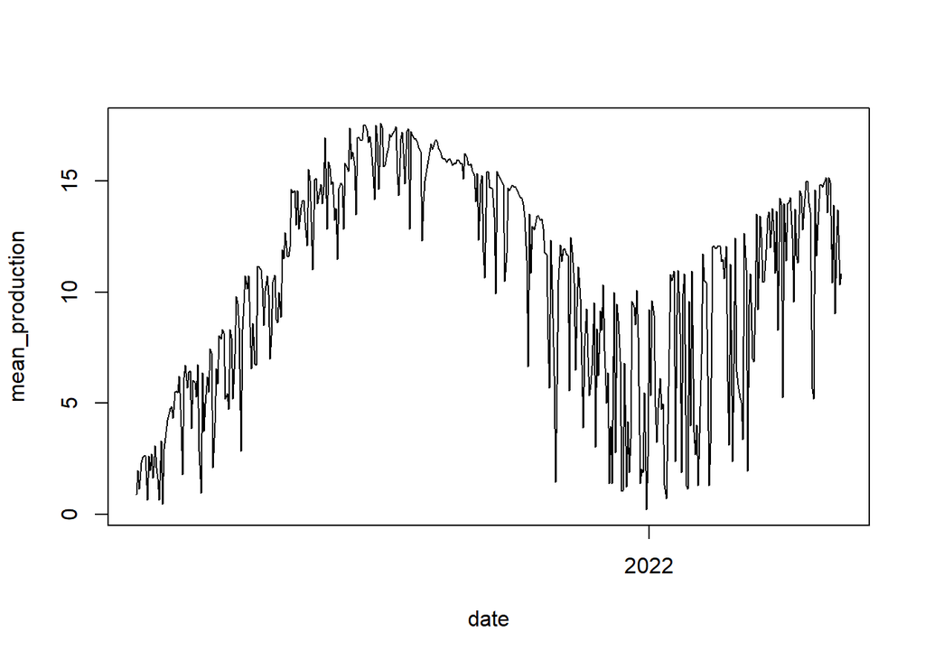

```r
plot(daily_prod,type="l")
```

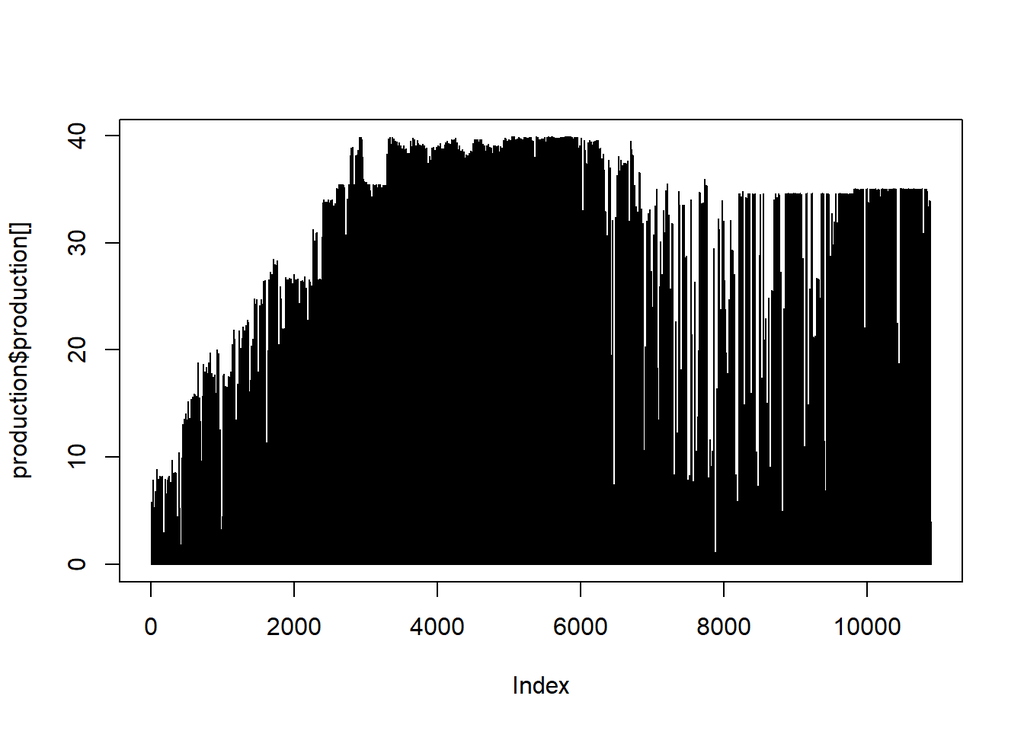

```r
windows()
plot(production$production[],type="l")
```

```r
windows()
```

# 3 Approach

The plot of the raw data is hard to interpret. So, we looked at the mean daily production plot.

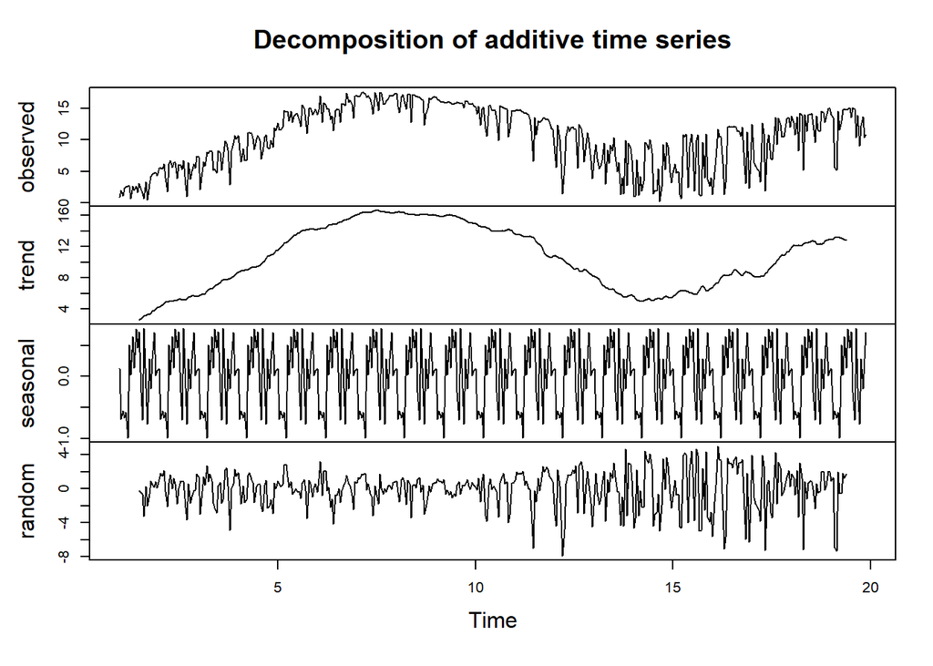

```r
decomposed<-decompose(ts(daily_prod$mean_production,freq=24))
plot(decomposed)

decomposed<-decompose(ts(daily_prod$mean_production,freq=24))
plot(decomposed)
```

Here we identify the number of days to forecast. We get the latest n_days and modify for forecasting. It creates date,hour and production columns for the upcoming days. Then, we match the actual data with forecasts.

```r
latest_available_prod_date=as.Date(max(production$date))
n_days=as.numeric(forecast_date-latest_available_prod_date)
forecasted_production=tail(production,n_days*24)
forecasted_production[,date:=date+n_days]
forecasted_production[,production:=NA]


production_with_forecast=rbind(production,forecasted_production)

forecast_table=data.table(date=forecast_date,hour=0:23,production=NA)

production_with_forecast=production_with_forecast[order(date,hour)]
production_series=ts(production_with_forecast[!is.na(production)]$production,frequency=24)

wide_weather=dcast(weather,date+hour~variable+lat+lon,value.var='value')

production_with_weather=merge(production_with_forecast,wide_weather,by=c('date','hour'))

production_with_weather[,hour:=as.character(hour)]
train_data=production_with_weather[!is.na(production)]
test_data=production_with_weather[is.na(production)]
```

# 3.1 Linear Regression Model 1

We added all of the variables when establishing our first model.

```r
lm_model=lm(production~.,train_data[,-c('date'),with=F])
summary(lm_model)
```

```
##
## Call:
## lm(formula = production ~ ., data = train_data[, -c("date"),
##     with = F])
##
## Residuals:
##     Min      1Q  Median      3Q     Max
## -35.983  -3.240   0.333   3.408  21.839
##
## Coefficients:
##                               Estimate Std. Error t value Pr(>|t|)
## (Intercept)                 -5.653e+01  4.895e+00 -11.548  < 2e-16 ***
## hour1                        4.637e-02  4.045e-01   0.115 0.908755
## hour10                       1.516e+01  5.013e-01  30.235  < 2e-16 ***
## hour11                       1.343e+01  5.261e-01  25.529  < 2e-16 ***
## hour12                       1.203e+01  5.453e-01  22.069  < 2e-16 ***
## hour13                       1.097e+01  5.573e-01  19.693  < 2e-16 ***
## hour14                       9.562e+00  5.628e-01  16.990  < 2e-16 ***
## hour15                       7.805e+00  5.615e-01  13.900  < 2e-16 ***
## hour16                       6.384e+00  5.200e-01  12.278  < 2e-16 ***
## hour17                      -8.251e-01  4.924e-01  -1.675 0.093875 .
## hour18                      -6.170e+00  4.682e-01 -13.178  < 2e-16 ***
## hour19                      -6.753e+00  4.485e-01 -15.055  < 2e-16 ***
## hour2                        4.422e-02  4.049e-01   0.109 0.913032
## hour20                      -5.442e+00  4.343e-01 -12.532  < 2e-16 ***
## hour21                      -4.607e+00  4.241e-01 -10.863  < 2e-16 ***
## hour22                       9.448e-02  4.060e-01   0.233 0.815999
## hour23                       2.711e-02  4.047e-01   0.067 0.946603
## hour3                        4.973e-02  4.054e-01   0.123 0.902368
## hour4                        3.456e-02  4.063e-01   0.085 0.932215
## hour5                        7.786e-02  4.071e-01   0.191 0.848318
## hour6                        1.074e+00  4.077e-01   2.634 0.008458 **
## hour7                        8.052e+00  4.069e-01  19.786  < 2e-16 ***
## hour8                        1.867e+01  4.084e-01  45.724  < 2e-16 ***
## hour9                        2.334e+01  4.141e-01  56.362  < 2e-16 ***
## quarter2                     8.734e-01  2.403e-01   3.634 0.000280 ***
## quarter3                     2.712e+00  3.174e-01   8.546  < 2e-16 ***
## quarter4                     2.305e+00  2.032e-01  11.343  < 2e-16 ***
## CLOUD_LOW_LAYER_36.25_33     4.448e-04  5.369e-03   0.083 0.933975
## CLOUD_LOW_LAYER_36.25_33.25 -1.616e-02  7.324e-03  -2.207 0.027337 *
```

[output cut: 25 more lines]

```
## TEMP_36.25_33                8.313e-02  1.266e-01   0.657 0.511439
## TEMP_36.25_33.25             1.010e+00  1.807e-01   5.590 2.33e-08 ***
## TEMP_36.25_33.5             -4.597e-01  1.200e-01  -3.830 0.000129 ***
## TEMP_36.5_33                 1.023e-01  9.889e-02   1.034 0.300993
## TEMP_36.5_33.25             -2.707e-01  1.658e-01  -1.633 0.102588
## TEMP_36.5_33.5              -5.922e-03  1.067e-01  -0.055 0.955760
## TEMP_36.75_33                6.545e-02  1.083e-01   0.605 0.545481
## TEMP_36.75_33.25             3.876e-01  1.445e-01   2.682 0.007320 **
## TEMP_36.75_33.5             -7.215e-01  1.151e-01  -6.270 3.76e-10 ***
## ---
## Signif. codes:  0 '***' 0.001 '**' 0.01 '*' 0.05 '.' 0.1 ' ' 1
##
## Residual standard error: 6.092 on 10833 degrees of freedom
## Multiple R-squared:  0.8184, Adjusted R-squared:  0.8174
## F-statistic: 787.5 on 62 and 10833 DF,  p-value: < 2.2e-16
```

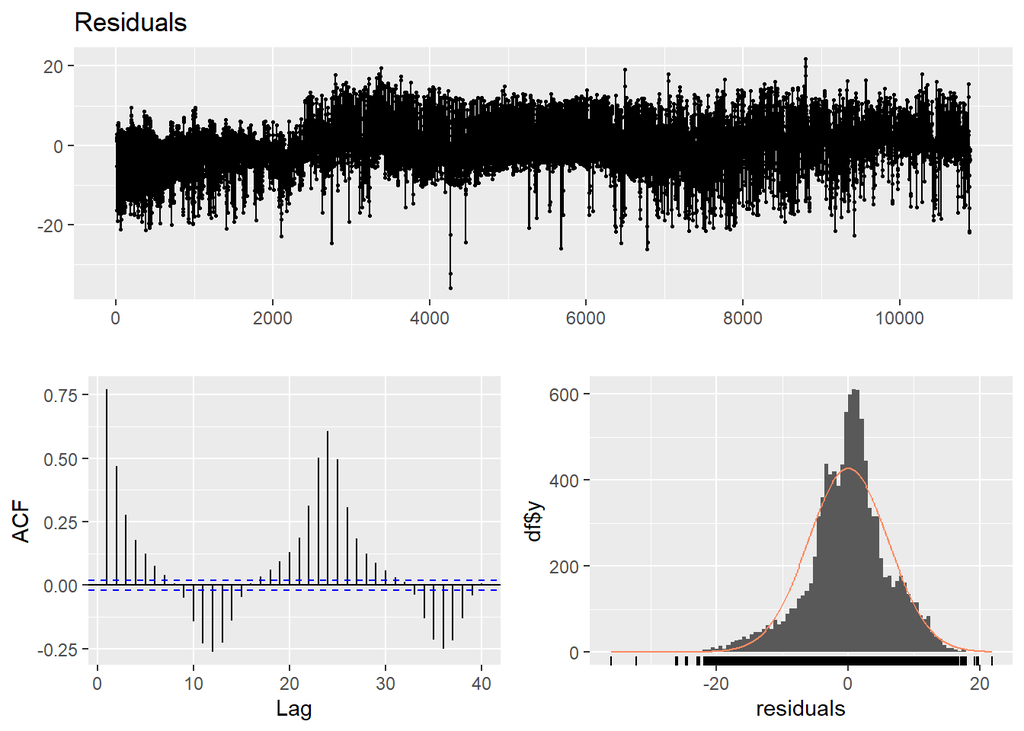

```
##
##  Breusch-Godfrey test for serial correlation of order up to 66
##
## data:  Residuals
## LM test = 8106.4, df = 66, p-value < 2.2e-16
```

```r
checkresiduals(lm_model)
```

```r
lm_forecast=predict(lm_model,test_data)
test_data[,forecasted:=as.numeric(lm_forecast)]

daily_max_production=production_with_forecast[,list(max_prod=max(production)),by=list(date)]
daily_max_production[,rolling_max:=frollapply(max_prod,30,max,na.rm=T)]

production_with_weather_capacity=merge(production_with_weather,daily_max_production,by=c('date'))
production_with_weather_capacity[,normalized_production:=production/rolling_max]

production_with_weather_capacity[,hour:=as.character(hour)]
train_data=production_with_weather_capacity[!is.na(production)]
test_data=production_with_weather_capacity[is.na(production)]
```

# 3.2 Model 2

Our model 2 is the normalized version of the first model.

```r
lm_model2=lm(normalized_production~.,production_with_weather_capacity[,-c('date','rolling_max','production','max_prod'),with=F])
summary(lm_model2)
```

```
##
## Call:
## lm(formula = normalized_production ~ ., data = production_with_weather_capacity[,
##     -c("date", "rolling_max", "production", "max_prod"), with = F])
##
## Residuals:
##      Min       1Q   Median       3Q      Max
## -0.95913 -0.05873 -0.00011  0.08203  0.55861
##
## Coefficients:
##                               Estimate Std. Error t value Pr(>|t|)
## (Intercept)                 -6.998e-01  1.231e-01  -5.683 1.36e-08 ***
## hour1                       -8.367e-05  1.003e-02  -0.008  0.99334
## hour10                       4.775e-01  1.248e-02  38.263  < 2e-16 ***
## hour11                       4.360e-01  1.308e-02  33.331  < 2e-16 ***
## hour12                       4.041e-01  1.353e-02  29.859  < 2e-16 ***
## hour13                       3.788e-01  1.382e-02  27.407  < 2e-16 ***
## hour14                       3.420e-01  1.395e-02  24.511  < 2e-16 ***
## hour15                       2.945e-01  1.392e-02  21.156  < 2e-16 ***
## hour16                       2.486e-01  1.288e-02  19.296  < 2e-16 ***
## hour17                       2.993e-02  1.221e-02   2.452  0.01423 *
## hour18                      -1.395e-01  1.161e-02 -12.015  < 2e-16 ***
## hour19                      -1.663e-01  1.113e-02 -14.940  < 2e-16 ***
## hour2                       -8.379e-04  1.004e-02  -0.083  0.93348
## hour20                      -1.348e-01  1.078e-02 -12.504  < 2e-16 ***
## hour21                      -1.151e-01  1.052e-02 -10.939  < 2e-16 ***
## hour22                       3.907e-03  1.007e-02   0.388  0.69793
## hour23                       1.504e-03  1.003e-02   0.150  0.88088
## hour3                       -1.294e-03  1.005e-02  -0.129  0.89755
## hour4                       -2.638e-03  1.008e-02  -0.262  0.79347
## hour5                       -2.059e-03  1.010e-02  -0.204  0.83836
## hour6                        2.573e-02  1.011e-02   2.545  0.01095 *
## hour7                        2.295e-01  1.009e-02  22.744  < 2e-16 ***
## hour8                        5.453e-01  1.013e-02  53.825  < 2e-16 ***
## hour9                        6.832e-01  1.027e-02  66.523  < 2e-16 ***
## quarter2                    -1.447e-02  6.093e-03  -2.374  0.01761 *
## quarter3                    -8.996e-03  7.940e-03  -1.133  0.25723
## quarter4                    -2.616e-02  5.220e-03  -5.011 5.51e-07 ***
## CLOUD_LOW_LAYER_36.25_33    -2.798e-05  1.361e-04  -0.206  0.83717
## CLOUD_LOW_LAYER_36.25_33.25 -3.241e-04  1.824e-04  -1.777  0.07562 .
```

[output cut: 26 more lines]

```
## TEMP_36.25_33.25             2.028e-02  4.454e-03   4.553 5.34e-06 ***
## TEMP_36.25_33.5             -5.227e-03  2.967e-03  -1.762  0.07817 .
## TEMP_36.5_33                 4.152e-03  2.429e-03   1.709  0.08743 .
## TEMP_36.5_33.25             -1.271e-02  4.067e-03  -3.125  0.00178 **
## TEMP_36.5_33.5              -3.235e-03  2.613e-03  -1.238  0.21568
## TEMP_36.75_33                5.805e-03  2.692e-03   2.157  0.03105 *
## TEMP_36.75_33.25            -4.408e-03  3.662e-03  -1.204  0.22864
## TEMP_36.75_33.5             -6.850e-03  2.902e-03  -2.360  0.01828 *
## ---
## Signif. codes:  0 '***' 0.001 '**' 0.01 '*' 0.05 '.' 0.1 ' ' 1
##
## Residual standard error: 0.1461 on 10137 degrees of freedom
##   (768 observations deleted due to missingness)
## Multiple R-squared:  0.8651, Adjusted R-squared:  0.8643
## F-statistic:  1049 on 62 and 10137 DF,  p-value: < 2.2e-16
```

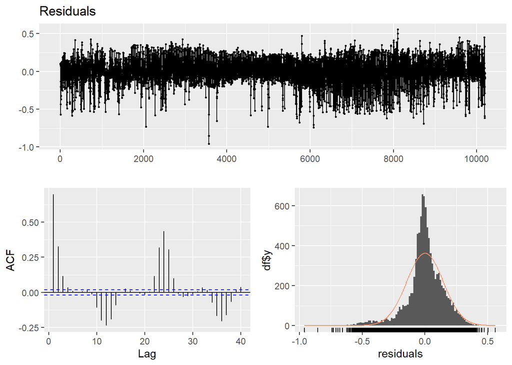

```
##
##  Breusch-Godfrey test for serial correlation of order up to 66
##
## data:  Residuals
## LM test = 6468.9, df = 66, p-value < 2.2e-16
```

```r
checkresiduals(lm_model2)
```

When we look at the ACF plot, it is evident that the first lag is very dominant. Therefore, it is worth adding lag 1 to our model to see how it responds.

# 3.3 Model 3

```r
production_with_weather_capacity[,lag1:=shift(normalized_production,1)]

lm_model3<-lm(normalized_production~.,production_with_weather_capacity[,-c('date','rolling_max','production','max_prod'),with=F])
summary(lm_model3)
```

```
##
## Call:
## lm(formula = normalized_production ~ ., data = production_with_weather_capacity[,
##     -c("date", "rolling_max", "production", "max_prod"), with = F])
##
## Residuals:
##      Min       1Q   Median       3Q      Max
## -0.90927 -0.02655 -0.00026  0.03732  0.52184
##
## Coefficients:
##                               Estimate Std. Error t value Pr(>|t|)
## (Intercept)                 -2.623e-01  8.776e-02  -2.989 0.002806 **
## hour1                        2.326e-05  7.144e-03   0.003 0.997403
## hour10                       2.156e-01  9.274e-03  23.252  < 2e-16 ***
## hour11                       1.842e-01  9.659e-03  19.067  < 2e-16 ***
## hour12                       1.800e-01  9.903e-03  18.171  < 2e-16 ***
## hour13                       1.730e-01  1.006e-02  17.192  < 2e-16 ***
## hour14                       1.478e-01  1.013e-02  14.588  < 2e-16 ***
## hour15                       1.201e-01  1.007e-02  11.931  < 2e-16 ***
## hour16                       3.513e-02  9.427e-03   3.727 0.000195 ***
## hour17                      -1.348e-01  8.852e-03 -15.234  < 2e-16 ***
## hour18                      -1.497e-01  8.273e-03 -18.095  < 2e-16 ***
## hour19                      -5.438e-02  8.007e-03  -6.791 1.18e-11 ***
## hour2                       -5.808e-04  7.150e-03  -0.081 0.935264
## hour20                      -2.444e-03  7.793e-03  -0.314 0.753858
## hour21                       1.357e-03  7.586e-03   0.179 0.858059
## hour22                       1.534e-03  7.170e-03   0.214 0.830620
## hour23                       5.749e-04  7.147e-03   0.080 0.935891
## hour3                       -6.268e-04  7.160e-03  -0.088 0.930237
## hour4                       -8.786e-04  7.177e-03  -0.122 0.902574
## hour5                       -2.143e-04  7.191e-03  -0.030 0.976224
## hour6                        2.681e-02  7.202e-03   3.722 0.000198 ***
## hour7                        2.180e-01  7.188e-03  30.331  < 2e-16 ***
## hour8                        3.942e-01  7.375e-03  53.452  < 2e-16 ***
## hour9                        3.071e-01  8.238e-03  37.277  < 2e-16 ***
## quarter2                     1.088e-02  4.345e-03   2.505 0.012259 *
## quarter3                     8.728e-03  5.655e-03   1.543 0.122760
## quarter4                    -1.203e-02  3.718e-03  -3.234 0.001225 **
## CLOUD_LOW_LAYER_36.25_33    -3.157e-05  9.691e-05  -0.326 0.744620
## CLOUD_LOW_LAYER_36.25_33.25 -2.721e-04  1.299e-04  -2.096 0.036150 *
```

[output cut: 27 more lines]

```
## TEMP_36.25_33.5             -4.805e-03  2.112e-03  -2.275 0.022924 *
## TEMP_36.5_33                -3.101e-03  1.731e-03  -1.792 0.073208 .
## TEMP_36.5_33.25             -1.928e-03  2.897e-03  -0.666 0.505692
## TEMP_36.5_33.5               3.433e-03  1.861e-03   1.844 0.065185 .
## TEMP_36.75_33                5.135e-03  1.916e-03   2.680 0.007371 **
## TEMP_36.75_33.25            -6.432e-03  2.607e-03  -2.467 0.013626 *
## TEMP_36.75_33.5              3.931e-04  2.067e-03   0.190 0.849186
## lag1                         7.601e-01  7.651e-03  99.343  < 2e-16 ***
## ---
## Signif. codes:  0 '***' 0.001 '**' 0.01 '*' 0.05 '.' 0.1 ' ' 1
##
## Residual standard error: 0.104 on 10135 degrees of freedom
##   (769 observations deleted due to missingness)
## Multiple R-squared:  0.9317, Adjusted R-squared:  0.9312
## F-statistic:  2193 on 63 and 10135 DF,  p-value: < 2.2e-16
```

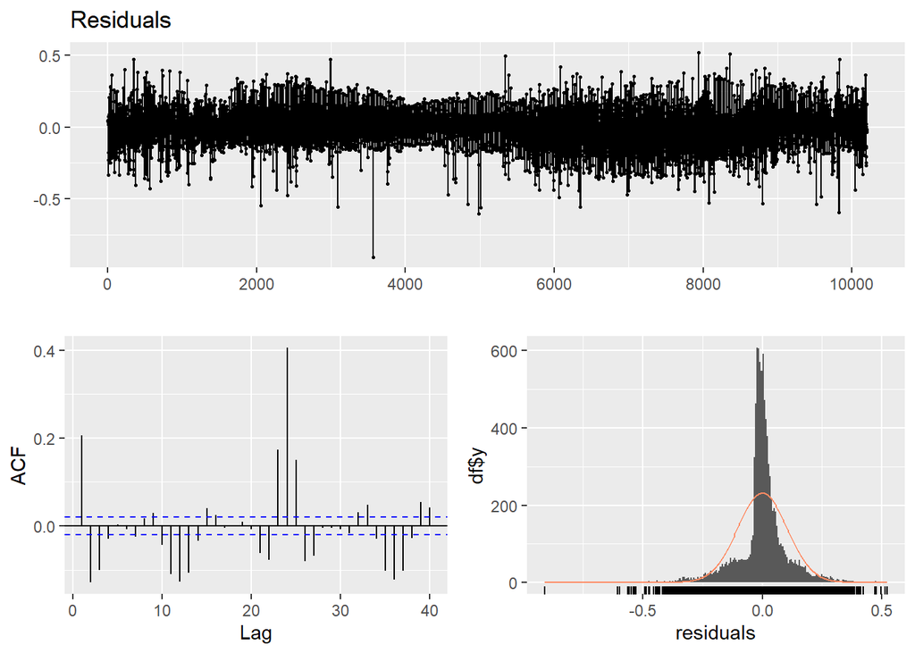

```
##
##  Breusch-Godfrey test for serial correlation of order up to 67
##
## data:  Residuals
## LM test = 2821.3, df = 67, p-value < 2.2e-16
```

```r
checkresiduals((lm_model3))
```

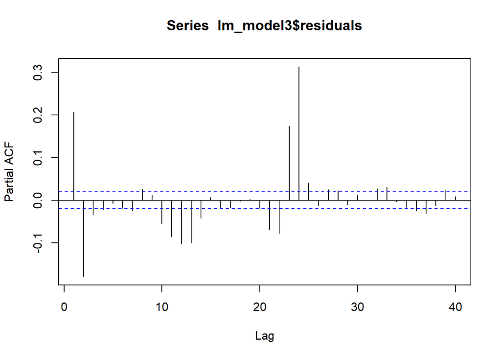

```r
pacf(lm_model3$residuals)
```

We can see that the value of the Adjusted R-Squared has increased significantly. Therefore model 3 is an improvement over the second model.

# 3.4 Model 4

In a similar manner, the PACF plot of model 3 shows that the 24th lag is significant. Therefore, we add it to our model to see how it changes the results.

```r
production_with_weather_capacity[,lag24:=shift(normalized_production,24)]

lm_model5<-lm(normalized_production~.,production_with_weather_capacity[,-c('date','rolling_max','production','max_prod'),with=F])
summary(lm_model5)
```

```
##
## Call:
## lm(formula = normalized_production ~ ., data = production_with_weather_capacity[,
##     -c("date", "rolling_max", "production", "max_prod"), with = F])
##
## Residuals:
##      Min       1Q   Median       3Q      Max
## -0.92562 -0.01980 -0.00198  0.03265  0.56286
##
## Coefficients:
##                               Estimate Std. Error t value Pr(>|t|)
## (Intercept)                 -4.622e-02  8.429e-02  -0.548  0.58350
## hour1                       -4.379e-04  6.834e-03  -0.064  0.94891
## hour10                       1.284e-01  9.328e-03  13.763  < 2e-16 ***
## hour11                       1.026e-01  9.627e-03  10.661  < 2e-16 ***
## hour12                       1.025e-01  9.822e-03  10.440  < 2e-16 ***
## hour13                       9.909e-02  9.944e-03   9.965  < 2e-16 ***
## hour14                       8.036e-02  9.957e-03   8.071 7.79e-16 ***
## hour15                       6.084e-02  9.842e-03   6.182 6.58e-10 ***
## hour16                      -7.063e-03  9.132e-03  -0.773  0.43929
## hour17                      -1.351e-01  8.475e-03 -15.944  < 2e-16 ***
## hour18                      -1.282e-01  7.950e-03 -16.126  < 2e-16 ***
## hour19                      -3.670e-02  7.685e-03  -4.776 1.82e-06 ***
## hour2                       -1.263e-03  6.841e-03  -0.185  0.85350
## hour20                       8.011e-03  7.466e-03   1.073  0.28331
## hour21                       9.072e-03  7.263e-03   1.249  0.21170
## hour22                       1.944e-03  6.860e-03   0.283  0.77683
## hour23                       7.586e-04  6.837e-03   0.111  0.91166
## hour3                       -1.512e-03  6.849e-03  -0.221  0.82533
## hour4                       -1.913e-03  6.867e-03  -0.279  0.78051
## hour5                       -1.668e-03  6.880e-03  -0.242  0.80841
## hour6                        1.997e-02  6.893e-03   2.897  0.00378 **
## hour7                        1.734e-01  7.034e-03  24.645  < 2e-16 ***
## hour8                        2.999e-01  7.713e-03  38.884  < 2e-16 ***
## hour9                        2.038e-01  8.590e-03  23.724  < 2e-16 ***
## quarter2                     1.079e-02  4.159e-03   2.595  0.00946 **
## quarter3                     1.032e-02  5.413e-03   1.907  0.05655 .
## quarter4                    -6.195e-03  3.568e-03  -1.736  0.08251 .
## CLOUD_LOW_LAYER_36.25_33    -7.493e-05  9.300e-05  -0.806  0.42047
## CLOUD_LOW_LAYER_36.25_33.25 -1.420e-04  1.248e-04  -1.138  0.25511
```

[output cut: 28 more lines]

```
## TEMP_36.5_33                -3.610e-03  1.656e-03  -2.181  0.02924 *
## TEMP_36.5_33.25             -5.760e-04  2.772e-03  -0.208  0.83538
## TEMP_36.5_33.5               2.106e-03  1.781e-03   1.183  0.23691
## TEMP_36.75_33                2.948e-03  1.834e-03   1.607  0.10814
## TEMP_36.75_33.25            -5.176e-03  2.497e-03  -2.073  0.03818 *
## TEMP_36.75_33.5              2.049e-03  1.983e-03   1.033  0.30147
## lag1                         6.969e-01  7.612e-03  91.548  < 2e-16 ***
## lag24                        1.947e-01  6.373e-03  30.556  < 2e-16 ***
## ---
## Signif. codes:  0 '***' 0.001 '**' 0.01 '*' 0.05 '.' 0.1 ' ' 1
##
## Residual standard error: 0.09946 on 10111 degrees of freedom
##   (792 observations deleted due to missingness)
## Multiple R-squared:  0.9376, Adjusted R-squared:  0.9372
## F-statistic:  2374 on 64 and 10111 DF,  p-value: < 2.2e-16
```

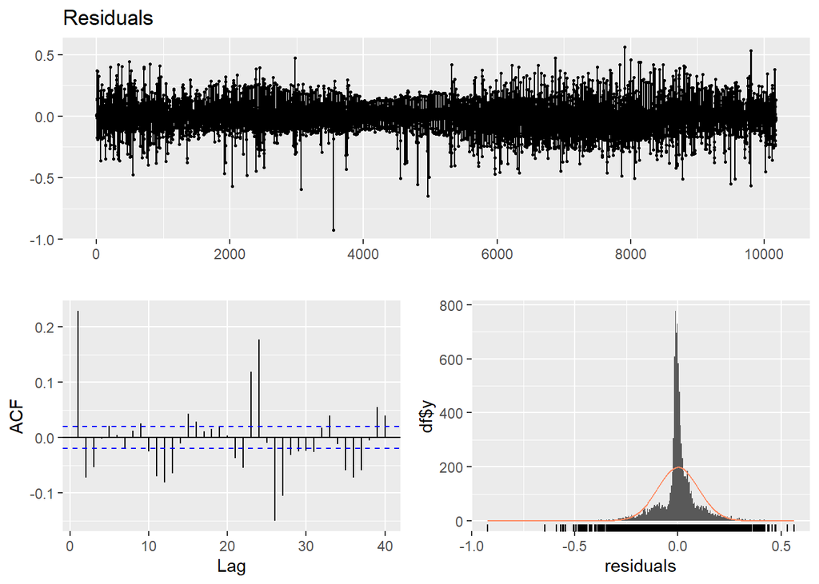

```
##
##  Breusch-Godfrey test for serial correlation of order up to 68
##
## data:  Residuals
## LM test = 1980.2, df = 68, p-value < 2.2e-16
```

```r
checkresiduals((lm_model5))
```

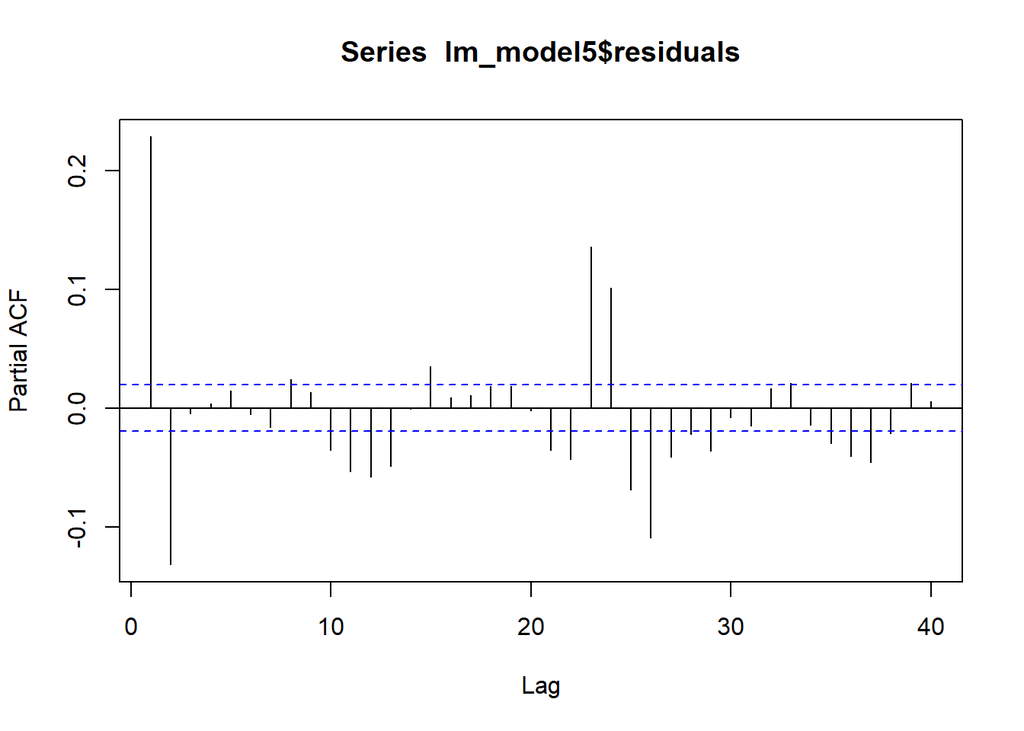

```r
pacf(lm_model5$residuals)
```

There is a small improvement in the model in terms of Adjusted R-Squared and F-Statistic. So, it is still an improvement, however a small one.

# 3.5 Model 5

```r
production_with_weather_capacity[,lag26:=shift(normalized_production,26)]


lm_model6<-lm(normalized_production~.,production_with_weather_capacity[,-c('date','rolling_max','production','max_prod'),with=F])
summary(lm_model6)
```

```
##
## Call:
## lm(formula = normalized_production ~ ., data = production_with_weather_capacity[,
##     -c("date", "rolling_max", "production", "max_prod"), with = F])
##
## Residuals:
##      Min       1Q   Median       3Q      Max
## -0.93927 -0.01877 -0.00047  0.02888  0.59379
##
## Coefficients:
##                               Estimate Std. Error t value Pr(>|t|)
## (Intercept)                 -1.120e-01  8.119e-02  -1.379  0.16781
## hour1                       -1.791e-04  6.588e-03  -0.027  0.97831
## hour10                       1.240e-01  8.986e-03  13.794  < 2e-16 ***
## hour11                       1.244e-01  9.304e-03  13.368  < 2e-16 ***
## hour12                       1.277e-01  9.502e-03  13.442  < 2e-16 ***
## hour13                       1.220e-01  9.612e-03  12.694  < 2e-16 ***
## hour14                       1.041e-01  9.627e-03  10.811  < 2e-16 ***
## hour15                       8.773e-02  9.527e-03   9.209  < 2e-16 ***
## hour16                       3.603e-02  8.927e-03   4.036 5.47e-05 ***
## hour17                      -7.166e-02  8.467e-03  -8.464  < 2e-16 ***
## hour18                      -6.156e-02  8.012e-03  -7.683 1.69e-14 ***
## hour19                      -7.847e-03  7.473e-03  -1.050  0.29370
## hour2                       -8.044e-04  6.590e-03  -0.122  0.90284
## hour20                       7.586e-05  7.197e-03   0.011  0.99159
## hour21                      -9.410e-03  7.027e-03  -1.339  0.18058
## hour22                       1.420e-03  6.608e-03   0.215  0.82980
## hour23                       5.703e-04  6.587e-03   0.087  0.93101
## hour3                       -8.983e-04  6.598e-03  -0.136  0.89171
## hour4                       -1.264e-03  6.615e-03  -0.191  0.84841
## hour5                       -9.860e-04  6.627e-03  -0.149  0.88173
## hour6                        1.847e-02  6.641e-03   2.782  0.00542 **
## hour7                        1.528e-01  6.815e-03  22.414  < 2e-16 ***
## hour8                        2.510e-01  7.628e-03  32.910  < 2e-16 ***
## hour9                        1.745e-01  8.338e-03  20.923  < 2e-16 ***
## quarter2                     7.046e-03  4.007e-03   1.759  0.07866 .
## quarter3                     9.175e-03  5.212e-03   1.760  0.07839 .
## quarter4                    -6.001e-03  3.435e-03  -1.747  0.08065 .
## CLOUD_LOW_LAYER_36.25_33     9.875e-06  8.969e-05   0.110  0.91232
## CLOUD_LOW_LAYER_36.25_33.25 -2.692e-04  1.205e-04  -2.235  0.02546 *
```

[output cut: 29 more lines]

```
## TEMP_36.5_33.25             -2.255e-03  2.669e-03  -0.845  0.39838
## TEMP_36.5_33.5               2.472e-03  1.715e-03   1.442  0.14937
## TEMP_36.75_33                3.637e-03  1.766e-03   2.059  0.03955 *
## TEMP_36.75_33.25            -3.919e-03  2.405e-03  -1.630  0.10319
## TEMP_36.75_33.5             -5.224e-04  1.911e-03  -0.273  0.78456
## lag1                         7.076e-01  7.338e-03  96.418  < 2e-16 ***
## lag24                        2.771e-01  6.791e-03  40.797  < 2e-16 ***
## lag26                       -2.012e-01  7.115e-03 -28.284  < 2e-16 ***
## ---
## Signif. codes:  0 '***' 0.001 '**' 0.01 '*' 0.05 '.' 0.1 ' ' 1
##
## Residual standard error: 0.09576 on 10108 degrees of freedom
##   (794 observations deleted due to missingness)
## Multiple R-squared:  0.9422, Adjusted R-squared:  0.9418
## F-statistic:  2534 on 65 and 10108 DF,  p-value: < 2.2e-16
```

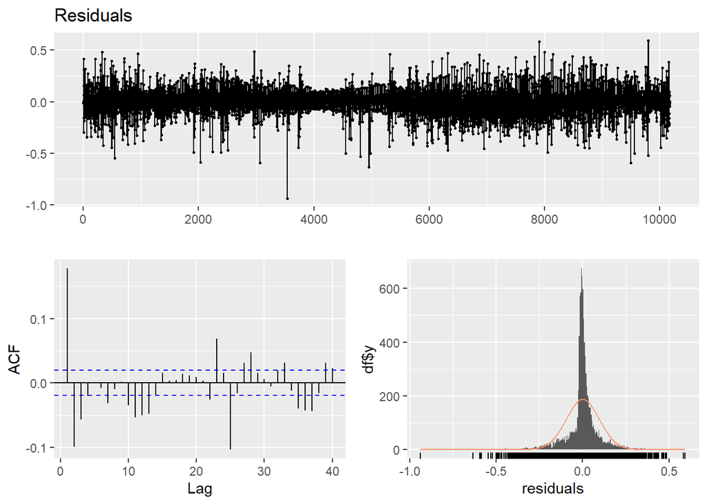

```
##
##  Breusch-Godfrey test for serial correlation of order up to 69
##
## data:  Residuals
## LM test = 1308.2, df = 69, p-value < 2.2e-16
```

```r
checkresiduals((lm_model6))
```

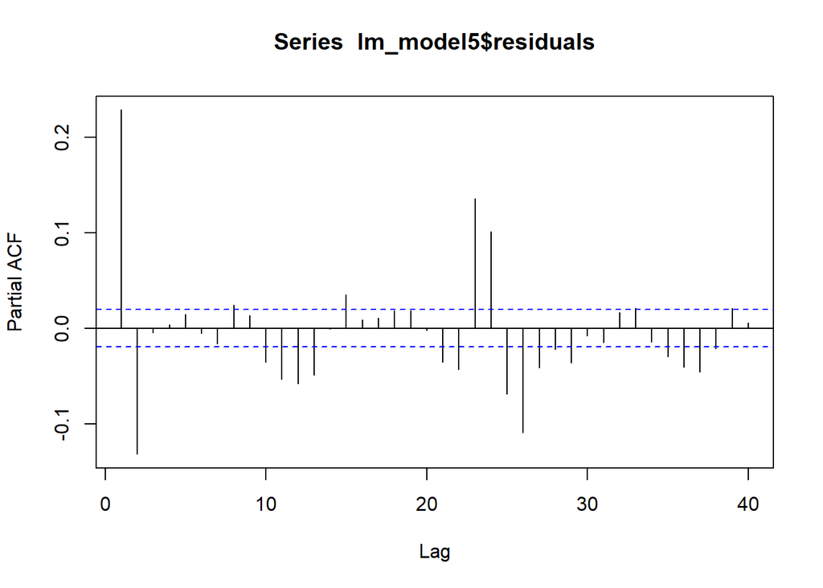

```r
pacf(lm_model5$residuals)
```